# Classification with Decision Trees and SVMs

Supervised Learning, Classification, Decision Trees (Entropy, Gini Impurity, Information Gain), Pruning, Overfitting, Support Vector Machines (SVM), Hyperplanes, Margins (Hard/Soft), Kernel Trick (Linear, RBF, Polynomial), C and Gamma Hyperparameters, Decision Boundaries.

### **Objectives:**

- Students will understand the core principles of **classification** in supervised learning.
- Students will grasp the intuition behind **Decision Trees** as a series of hierarchical rules and understand the concepts of splitting criteria (Gini/Entropy) and the need for **pruning** to prevent overfitting.
- Students will understand the goal of **Support Vector Machines (SVMs)** to find an optimal separating hyperplane that maximizes the margin between classes.
- Students will learn the role of the **kernel trick** (specifically the RBF kernel) in enabling SVMs to solve non-linearly separable problems.
- Students will implement, visualize, and interpret Decision Tree and SVM classifiers using `scikit-learn`.
- Students will understand the critical role of hyperparameters, such as `max_depth` for Decision Trees and `C` and `gamma` for SVMs, in controlling model complexity.
- Students will critically **compare the decision boundaries** and performance of both models on the same dataset.

### **Setup: Install and Import Libraries**

For this lab, we will use `mlxtend` to visualize the decision boundaries of our classifiers, which is essential for building intuition.

```python
# Install mlxtend for plotting decision boundaries
!pip install mlxtend -q

# Import libraries
import pandas as pd
import numpy as np
import matplotlib.pyplot as plt
import seaborn as sns
import sklearn
import mlxtend

# Scikit-learn for models, datasets, and preprocessing
from sklearn.datasets import make_moons, load_breast_cancer
from sklearn.model_selection import train_test_split
from sklearn.preprocessing import StandardScaler
from sklearn.tree import DecisionTreeClassifier, plot_tree
from sklearn.svm import SVC
from sklearn.metrics import accuracy_score

# MLxtend for visualizing decision regions
from mlxtend.plotting import plot_decision_regions

# Set plot style for better aesthetics
sns.set_theme(style="whitegrid")
sns.set_context("notebook", font_scale=1.2)

# Suppress warnings for cleaner output
import warnings
warnings.filterwarnings('ignore')

print(f"MLxtend Version: {mlxtend.__version__}")
print(f"Scikit-learn Version: {sklearn.__version__}")
```

```
MLxtend Version: 0.23.4
Scikit-learn Version: 1.6.1
```

### **Part 1: The Dataset - Non-Linearly Separable Data**

We will start with a synthetic dataset that is impossible to separate with a straight line. The `make_moons` dataset is perfect for this, as it immediately highlights the need for more sophisticated models than simple linear classifiers. Our goal is to train models that can learn the curved "moon" shapes.

**Tasks:**

- Generate and visualize the `make_moons` dataset.
- Perform a standard train-test split and scale the features.

```
--- Part 1: Dataset Generation and Setup ---
```

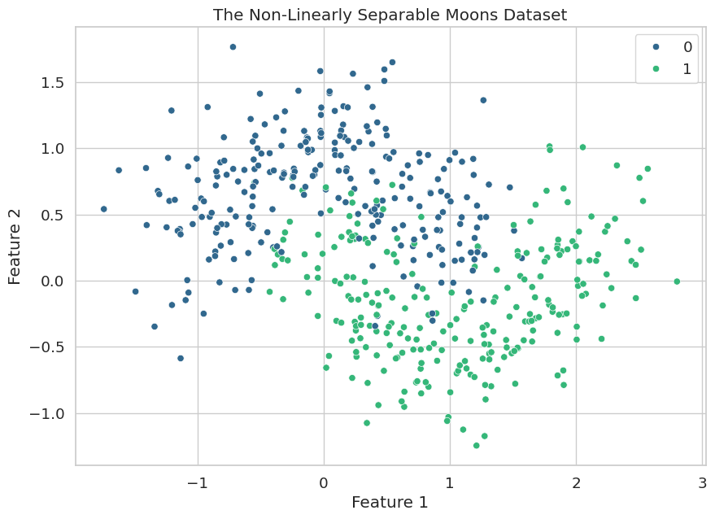

```
Training data shape: (350, 2)
Test data shape: (150, 2)
```

```python
print("--- Part 1: Dataset Generation and Setup ---")

# 1. Generate the make_moons dataset
X, y = make_moons(n_samples=500, noise=0.3, random_state=42)

# 2. Visualize the dataset
plt.figure(figsize=(10, 7))
sns.scatterplot(x=X[:, 0], y=X[:, 1], hue=y, palette='viridis')
plt.title('The Non-Linearly Separable Moons Dataset')
plt.xlabel('Feature 1')
plt.ylabel('Feature 2')
plt.show()

# 3. Split data and scale features
X_train, X_test, y_train, y_test = train_test_split(X, y, test_size=0.3, random_state=42, stratify=y)

scaler = StandardScaler()
X_train_scaled = scaler.fit_transform(X_train)
X_test_scaled = scaler.transform(X_test)

print(f"Training data shape: {X_train_scaled.shape}")
print(f"Test data shape: {X_test_scaled.shape}")
```

### **Part 2: The Decision Tree Classifier**

A Decision Tree is an intuitive, flowchart-like model. It learns a series of if/else questions based on the feature values, splitting the data at each step to create groups that are as "pure" (homogenous in class) as possible.

A key danger with Decision Trees is **overfitting**. If left unconstrained, a tree will grow until it perfectly memorizes every single point in the training data, creating a complex, jagged decision boundary that fails to generalize to new data. We can prevent this by **pruning** the tree, most commonly by setting a `max_depth`.

```
--- Part 2: Decision Trees - Overfitting vs. Pruning ---
Overfit Tree - Train Accuracy: 1.0000
Overfit Tree - Test Accuracy:  0.8667
Pruned Tree (max_depth=3) - Train Accuracy: 0.9057
Pruned Tree (max_depth=3) - Test Accuracy:  0.8800
```

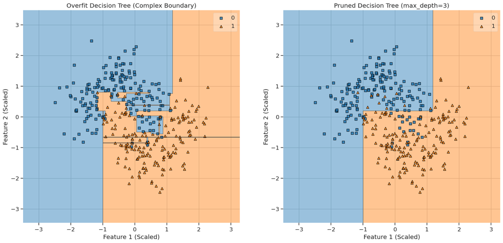

```python
print("\n--- Part 2: Decision Trees - Overfitting vs. Pruning ---")

# 1. Train a fully grown (overfit) Decision Tree
# By not setting max_depth, the tree can grow as deep as it needs to.
dt_overfit = DecisionTreeClassifier(random_state=42)
dt_overfit.fit(X_train_scaled, y_train)

# 2. Train a pruned (regularized) Decision Tree
dt_pruned = DecisionTreeClassifier(max_depth=3, random_state=42)
dt_pruned.fit(X_train_scaled, y_train)

# 3. Evaluate both models
print(f"Overfit Tree - Train Accuracy: {accuracy_score(y_train, dt_overfit.predict(X_train_scaled)):.4f}")
print(f"Overfit Tree - Test Accuracy:  {accuracy_score(y_test, dt_overfit.predict(X_test_scaled)):.4f}")
print(f"Pruned Tree (max_depth=3) - Train Accuracy: {accuracy_score(y_train, dt_pruned.predict(X_train_scaled)):.4f}")
print(f"Pruned Tree (max_depth=3) - Test Accuracy:  {accuracy_score(y_test, dt_pruned.predict(X_test_scaled)):.4f}")

# 4. Visualize the decision boundaries
fig, (ax1, ax2) = plt.subplots(1, 2, figsize=(20, 9))

plot_decision_regions(X_train_scaled, y_train, clf=dt_overfit, ax=ax1)
ax1.set_title('Overfit Decision Tree (Complex Boundary)')
ax1.set_xlabel('Feature 1 (Scaled)')
ax1.set_ylabel('Feature 2 (Scaled)')


plot_decision_regions(X_train_scaled, y_train, clf=dt_pruned, ax=ax2)
ax2.set_title('Pruned Decision Tree (max_depth=3)')
ax2.set_xlabel('Feature 1 (Scaled)')
ax2.set_ylabel('Feature 2 (Scaled)')

plt.show()

# INSIGHT: The overfit tree has a near-perfect training accuracy but lower test accuracy. Its boundary is highly complex.
# The pruned tree has a slightly lower training accuracy but generalizes better to the test set. Its boundary is much simpler.
```

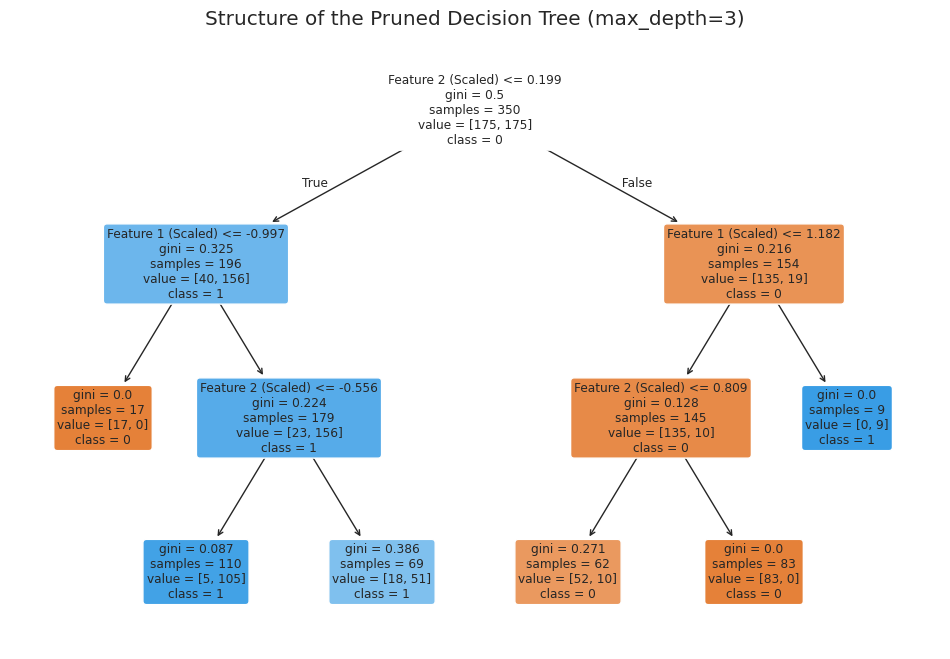

```python
# 5. Visualize the pruned Decision Tree structure
plt.figure(figsize=(12, 8))
plot_tree(dt_pruned, filled=True, feature_names=['Feature 1 (Scaled)', 'Feature 2 (Scaled)'], class_names=['0', '1'], rounded=True)
plt.title('Structure of the Pruned Decision Tree (max_depth=3)')
plt.show()

# INSIGHT: This plot shows the sequence of splits the pruned tree makes based on the scaled features.
```

### **Part 3: The Support Vector Machine (SVM) Classifier**

The Support Vector Machine (SVM) takes a different approach. For a classification task, it seeks to find the hyperplane (a line in 2D, a plane in 3D, etc.) that best separates the classes by maximizing the **margin**, or the distance between the hyperplane and the nearest data points of any class.

For non-linear data like our moons, SVMs use the **kernel trick**. The **Radial Basis Function (RBF) kernel** is a popular choice that can create complex, non-linear decision boundaries by effectively mapping the data to a higher-dimensional space.

**Key Hyperparameters for RBF SVM:**

- **`C` (Regularization parameter)**: Controls the trade-off between maximizing the margin and minimizing classification errors. A **low `C`** creates a wider margin but may misclassify some training points (more tolerant, smoother boundary). A **high `C`** creates a narrow margin and tries to classify every training point correctly, which can lead to overfitting.
- **`gamma`**: Defines the influence of a single training example. A **low `gamma`** means each point has a far-reaching influence, leading to a smoother, more general boundary. A **high `gamma`** means each point has a very localized influence, leading to a more complex, wiggly boundary that can overfit.

```
--- Part 3: Support Vector Machines with RBF Kernel ---
RBF SVM - Test Accuracy: 0.9133
```

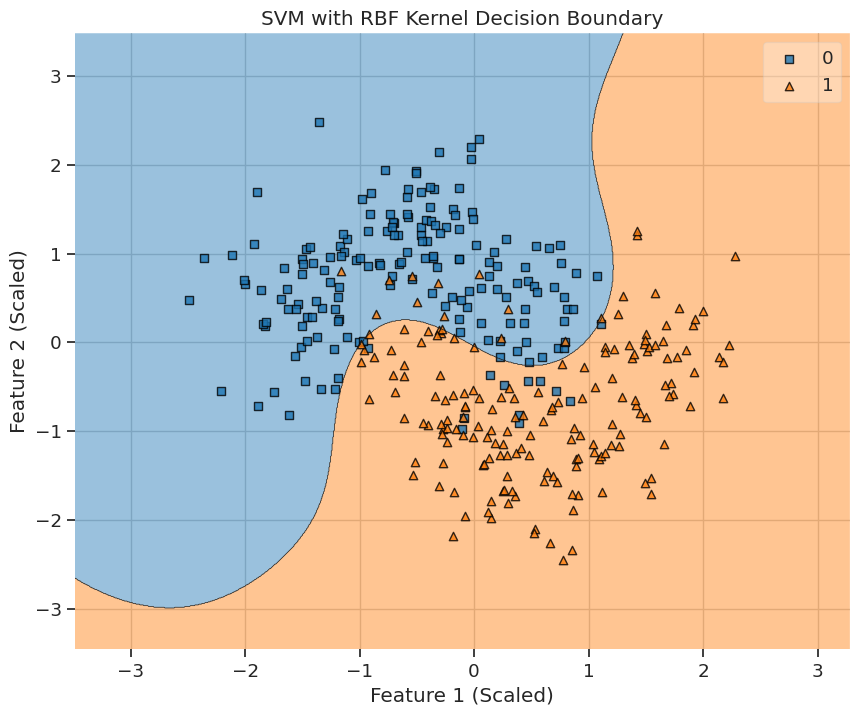

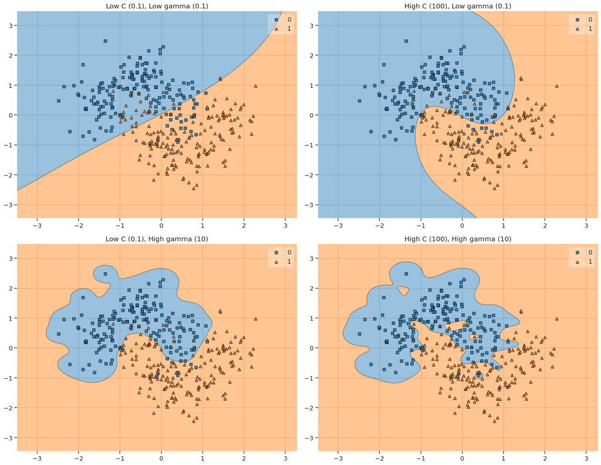

```python
print("\n--- Part 3: Support Vector Machines with RBF Kernel ---")

# 1. Train an SVM with default parameters (C=1.0, gamma='scale')
svm_rbf = SVC(kernel='rbf', random_state=42)
svm_rbf.fit(X_train_scaled, y_train)

print(f"RBF SVM - Test Accuracy: {accuracy_score(y_test, svm_rbf.predict(X_test_scaled)):.4f}")

# 2. Visualize the decision boundary of the SVM
plt.figure(figsize=(10, 8))
plot_decision_regions(X_train_scaled, y_train, clf=svm_rbf)
plt.title('SVM with RBF Kernel Decision Boundary')
plt.xlabel('Feature 1 (Scaled)')
plt.ylabel('Feature 2 (Scaled)')
plt.show()

# INSIGHT: The SVM with the RBF kernel creates a smooth, non-linear boundary that effectively separates the two moons.

# 3. Visualize the effect of C and gamma
fig, axes = plt.subplots(2, 2, figsize=(18, 14))

# Low C, Low gamma -> Smooth, general boundary
svm_1 = SVC(kernel='rbf', C=0.1, gamma=0.1, random_state=42).fit(X_train_scaled, y_train)
plot_decision_regions(X_train_scaled, y_train, clf=svm_1, ax=axes[0, 0])
axes[0, 0].set_title('Low C (0.1), Low gamma (0.1)')

# High C, Low gamma -> Tries harder to fit, but still smooth
svm_2 = SVC(kernel='rbf', C=100, gamma=0.1, random_state=42).fit(X_train_scaled, y_train)
plot_decision_regions(X_train_scaled, y_train, clf=svm_2, ax=axes[0, 1])
axes[0, 1].set_title('High C (100), Low gamma (0.1)')

# Low C, High gamma -> Localized influence, wiggly boundary
svm_3 = SVC(kernel='rbf', C=0.1, gamma=10, random_state=42).fit(X_train_scaled, y_train)
plot_decision_regions(X_train_scaled, y_train, clf=svm_3, ax=axes[1, 0])
axes[1, 0].set_title('Low C (0.1), High gamma (10)')

# High C, High gamma -> Highly complex, overfit boundary
svm_4 = SVC(kernel='rbf', C=100, gamma=10, random_state=42).fit(X_train_scaled, y_train)
plot_decision_regions(X_train_scaled, y_train, clf=svm_4, ax=axes[1, 1])
axes[1, 1].set_title('High C (100), High gamma (10)')

plt.tight_layout()
plt.show()
```

### **Part 4: Model Comparison & Discussion**

| Feature | Decision Tree | Support Vector Machine (SVM) |
| --- | --- | --- |
| **Model Type** | Rule-based ("White Box") | Margin-based ("Black Box") |
| **Interpretability** | **High**. The decision path is easy to understand and visualize. | **Low**. The decision function, especially with kernels, is not intuitive. |
| **Decision Boundary** | Axis-parallel (rectilinear) splits, can be jagged. | Can be linear or smooth and non-linear (with kernels). |
| **Key Strengths** | Very fast, handles categorical and numerical data natively, robust to feature scaling. | Effective in high dimensions, memory efficient, models complex boundaries. |
| **Key Weaknesses** | Highly prone to overfitting, can be unstable (small data changes can drastically change the tree). | Can be slow on very large datasets, less interpretable, requires careful feature scaling and hyperparameter tuning. |
| **When to Use** | When interpretability is paramount; as a strong baseline; in ensembles like Random Forest. | For complex but not massive datasets; when high accuracy is the primary goal and interpretability is secondary. |

### **Lab Tasks & Exercises**

Now, apply these models to a real-world, high-dimensional dataset. The Breast Cancer Wisconsin dataset is a classic binary classification problem.

```python
# --- TASK 1: Apply Models to a Real-World Dataset ---
# 1. Load the Breast Cancer dataset from scikit-learn.
# 2. Perform a train-test split and scale the data.
# 3. Train both a pruned Decision Tree (e.g., max_depth=4) and an RBF SVM (default parameters) on the data.
# 4. Compare their test set accuracies. Which one performs better out-of-the-box?

# YOUR CODE HERE
# # Load data
# cancer = load_breast_cancer()
# X_cancer, y_cancer = cancer.data, cancer.target
#
# # Split and scale
# X_train_c, X_test_c, y_train_c, y_test_c = train_test_split(X_cancer, y_cancer, test_size=0.3, random_state=42, stratify=y_cancer)
# scaler_c = StandardScaler()
# X_train_c_scaled = scaler_c.fit_transform(X_train_c)
# X_test_c_scaled = scaler_c.transform(X_test_c)
#
# # Train and evaluate Decision Tree
# dt_cancer = DecisionTreeClassifier(max_depth=4, random_state=42).fit(X_train_c_scaled, y_train_c)
# acc_dt_cancer = accuracy_score(y_test_c, dt_cancer.predict(X_test_c_scaled))
#
# # Train and evaluate SVM
# svm_cancer = SVC(kernel='rbf', random_state=42).fit(X_train_c_scaled, y_train_c)
# acc_svm_cancer = accuracy_score(y_test_c, svm_cancer.predict(X_test_c_scaled))
#
# print("--- Task 1: Breast Cancer Dataset Results ---")
# print(f"Pruned Decision Tree Test Accuracy: {acc_dt_cancer:.4f}")
# print(f"RBF SVM Test Accuracy: {acc_svm_cancer:.4f}")


# --- TASK 2: Hyperparameter Tuning for SVM ---
# Using the Breast Cancer data, try to improve the SVM's accuracy from Task 1 by experimenting with C and gamma.
# Try at least two different combinations. For example:
#   - A high C and default gamma (e.g., C=100)
#   - A default C and a low gamma (e.g., gamma=0.01)
# Does tuning help?

# YOUR CODE HERE
# svm_c1 = SVC(C=100, random_state=42).fit(X_train_c_scaled, y_train_c)
# acc_svm_c1 = accuracy_score(y_test_c, svm_c1.predict(X_test_c_scaled))
# print(f"\n--- Task 2: SVM Tuning ---")
# print(f"SVM (C=100) Test Accuracy: {acc_svm_c1:.4f}")
#
# svm_g1 = SVC(gamma=0.01, random_state=42).fit(X_train_c_scaled, y_train_c)
# acc_svm_g1 = accuracy_score(y_test_c, svm_g1.predict(X_test_c_scaled))
# print(f"SVM (gamma=0.01) Test Accuracy: {acc_svm_g1:.4f}")


# --- TASK 3: Changing the SVM Kernel ---
# Go back to the original `make_moons` dataset.
# Train an SVM but this time use a polynomial kernel: `SVC(kernel='poly', degree=3)`.
# Visualize its decision boundary using `plot_decision_regions`.
# How does the polynomial kernel's boundary look compared to the RBF kernel's boundary?

# YOUR CODE HERE
# svm_poly = SVC(kernel='poly', degree=3, random_state=42).fit(X_train_scaled, y_train)
# print(f"\n--- Task 3: Polynomial Kernel on Moons Dataset ---")
# print(f"Polynomial SVM Test Accuracy: {accuracy_score(y_test, svm_poly.predict(X_test_scaled)):.4f}")
# plt.figure(figsize=(10, 8))
# plot_decision_regions(X_train_scaled, y_train, clf=svm_poly)
# plt.title('SVM with Polynomial Kernel (degree=3)')
# plt.show()
```

Prepared By

**Md. Atikuzzaman**  
Lecturer  
Department of Computer Science and Engineering  
Green University of Bangladesh  
Email: atik@cse.green.edu.bd